# Conversor

Aaron Mulvey

12/11/2024

## Definir Variables para Reproducción

Las siguientes variables definen rutas, nombres de archivos y configuraciones necesarias para garantizar la reproducibilidad del análisis.

```r
# Configuración del directorio de trabajo
setwd("../Scripts")

# Variables generales
atleta <- "June"
directorio <- "../Atletas"

# Subdirectorios para importar y exportar datos
subdir_importar <- "Import"
subdir_exportar <- "Export"

# Nombres de archivos
archivos <- list(
  fit_importar = "sesion1.rda",
  csv_importar = "metricas.xlsx",
  guardar_sesiones = "sesiones.rda",
  guardar_completo = "sesiones_completo.rda",
  guardar_limpias = "sesiones_limpias.rda",
  guardar_records = "records.rda",
  guardar_records_lista = "records_lista.rda",
  guardar_resumenes = "records_resumenes.rda",
  guardar_laps = "laps.rda",
  guardar_laps_lista = "laps_lista.rda"
)

# Rutas de importación y exportación
ruta_importar <- file.path(directorio, atleta, subdir_importar)
ruta_exportar <- file.path(directorio, atleta, subdir_exportar)

# Lista de archivos FIT en la carpeta de importación
archivos_fit <- list.files(ruta_importar, full.names = TRUE)
```

## Leer Nuevos Archivos

En este paso, se procesan los archivos FIT para extraer información relevante de sesiones y registros. Se aplican funciones para leer y unificar los datos en dataframes estructurados.

```r
# Leer sesiones desde archivos FIT
sesiones <- archivos_fit %>%
  lapply(function(file) {
    getMessagesByType(readFitFile(file), "session")
  }) %>%
  bind_rows() # Unir todas las sesiones en un único dataframe

# Leer registros desde archivos FIT
records_lista_nueva <- archivos_fit %>%
  lapply(function(file) {
    getMessagesByType(readFitFile(file), "record")
  }) %>%
  lapply(bind_rows) # Unir los registros leídos en una lista de dataframes

###################### CREAR FUNCION DE LECTURA UNO DE LOS LAPS

laps_lista_nueva <- archivos_fit %>%
  lapply(function(file) {
    getMessagesByType(readFitFile(file), "lap")
  })
```

## Importar Datos Existentes

En este paso, se cargan los datos previamente procesados y guardados en archivos locales. Esto incluye sesiones antiguas, registros históricos, datos de Excel y laps previas.

```r
# Cargar datos de sesiones antiguas
load(paste(file = paste(ruta_exportar,
                        archivos$guardar_sesiones,
                        sep = '/')))

# Cargar registros (records) antiguos
load(paste(file = paste(ruta_exportar,
                        archivos$guardar_records_lista,
                        sep = '/')))

# Importar datos desde un archivo Excel
excel <- read_excel(file.path(ruta_exportar, archivos$csv_importar))



# Cargar datos de laps previas
load(paste(file = paste(ruta_exportar,
                        archivos$guardar_laps_lista,
                        sep = '/')))
```

```r
###################### UNIMOS SESIONES NUEVAS Y VIEJAS

sesiones_viejas <- rbind.data.frame(sesiones_viejas,
                                    sesiones)

###################### UNIMOS LISTAS DE RECORDS

records_lista <- append(records_lista,
                        records_lista_nueva)


###################### CREAMOS UN GRAN DATRAFRAME CON LOS REGISTROS

records_dataframe <- records_lista %>%
  bind_rows()


###################### UNIMOS LAPS ANTIGUAS Y LAPS NUEVAS

laps_lista <- append(laps_lista,
                     laps_lista_nueva)

###################### CREAR DATAFRAME LAPS

laps_lista <- lapply(laps_lista, function(df) {
  if ("left_right_balance" %in% colnames(df)) {
    df <- df %>% mutate(left_right_balance = as.character(left_right_balance))
  }
  return(df)
})

# Unir la lista de laps en un único dataframe
laps_dataframe <- laps_lista %>%
  bind_rows()
```

## Crear Cadena de Unión entre Excel y Archivo Binario

En este paso, se crea un dataframe consolidado a partir de las sesiones antiguas, descomponiendo la columna de timestamp y formateando las fechas.

```r
###################### CREAMOS DATAFRAME DE SESIONES CON CADENA DE UNION
# SEPARA LA COLUMNA timestamp EN FECHA Y HORA, Y FORMATEA LA FECHA
sesiones_union <- sesiones_viejas %>%
  tidyr::separate(col = timestamp,
                  into = c("date", "hour"),
                  sep = " ") %>%
  mutate(date = ymd(date)) %>%  # CONVIERTE LA COLUMNA date A FORMATO DE FECHA
  mutate(hour = NULL)           # ELIMINA LA COLUMNA hour, YA NO ES NECESARIA
```

## Detección y Tratamiento de Outliers en las Sesiones

En este paso, se detectan y tratan los valores atípicos en las métricas principales de las sesiones. Se utiliza un enfoque combinado de visualización, sustitución manual y métodos automáticos.

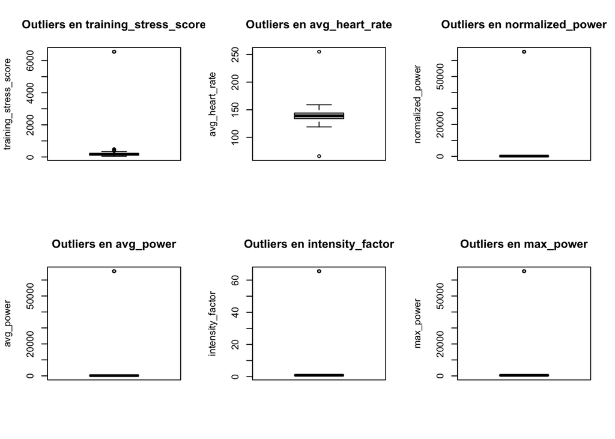

```r
###################### DETECCION DE OUTLIERS
# GRAFICAR LOS OUTLIERS EN LAS MÉTRICAS CLAVE
metricas <- c("training_stress_score", "avg_heart_rate",
              "normalized_power", "avg_power",
              "intensity_factor", "max_power")

par(mfrow = c(2, 3)) # CONFIGURAR GRID PARA GRAFICAR
for (metrica in metricas) {
  boxplot(sesiones_viejas[[metrica]],
          main = paste("Outliers en", metrica),
          ylab = metrica)
}
```

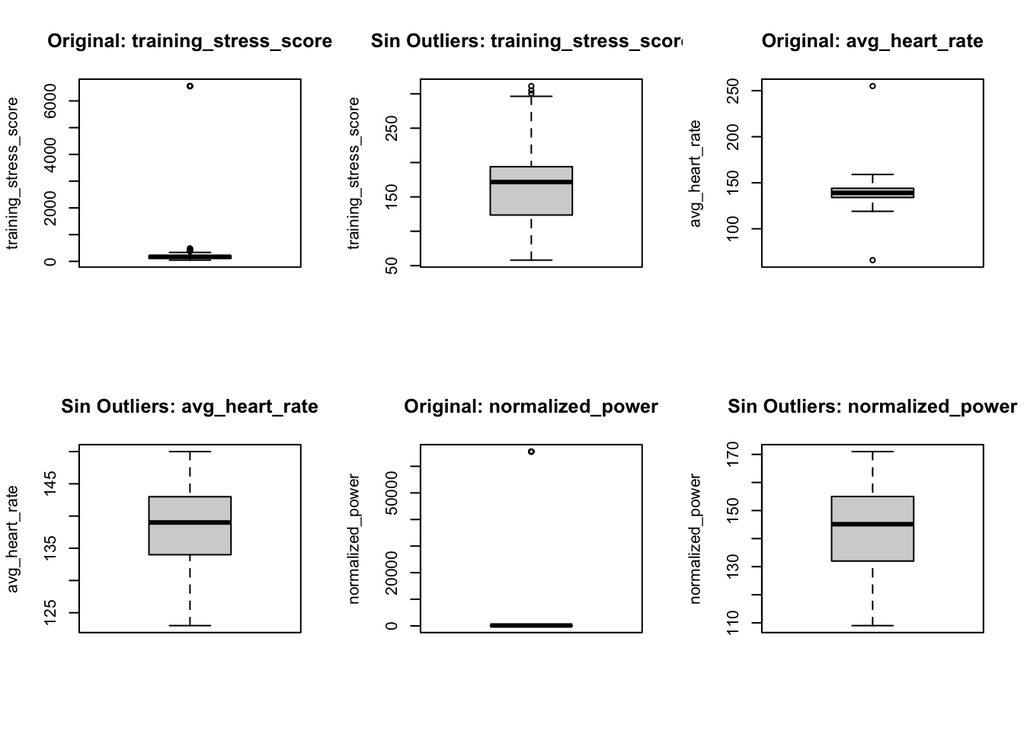

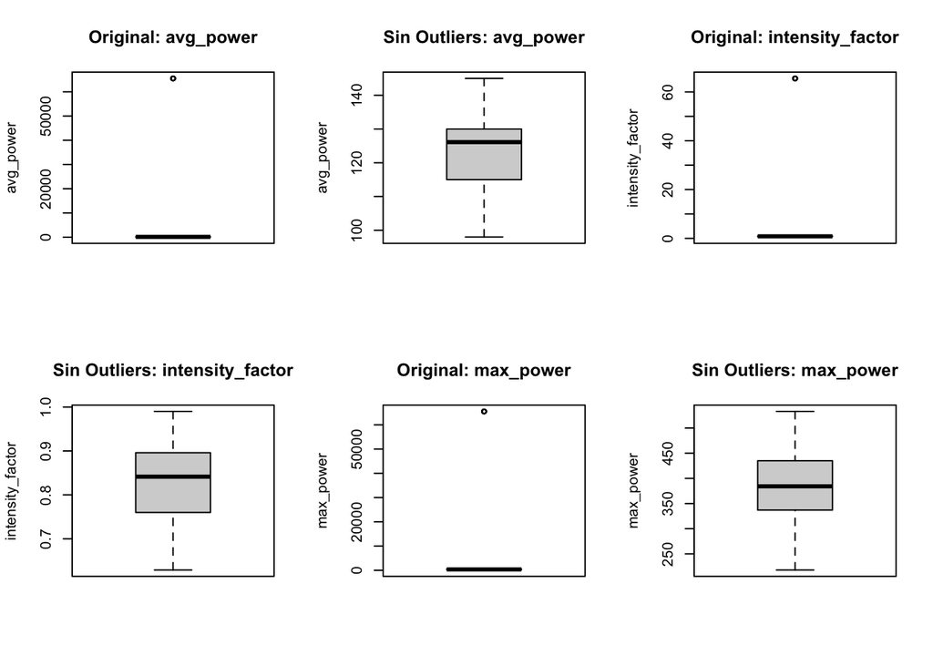

```r
par(mfrow = c(1, 1)) # REVERTIR GRID

###################### FUNCION PARA SUSTITUCION DE OUTLIERS
# IMPUTA OUTLIERS UTILIZANDO CUANTILES
impute_outliers <- function(x, lower_quantile = 0.05, upper_quantile = 0.95) {
  quantiles <- quantile(x, c(lower_quantile, upper_quantile), na.rm = TRUE)
  x[x < quantiles[1]] <- mean(x, na.rm = TRUE)  # REEMPLAZAR OUTLIERS INFERIORES
  x[x > quantiles[2]] <- median(x, na.rm = TRUE) # REEMPLAZAR OUTLIERS SUPERIORES
  return(x)
}

###################### SUSTITUCION MANUAL DE VALORES EXTREMOS
# AJUSTE MANUAL DE ALGUNOS OUTLIERS ESPECÍFICOS
sesiones_union <- sesiones_union %>%
  mutate(
    training_stress_score = ifelse(training_stress_score > 6000,
                                   median(training_stress_score),
                                   training_stress_score),
    intensity_factor = ifelse(intensity_factor > 6,
                              quantile(intensity_factor, 0.5),
                              intensity_factor),
    avg_power = ifelse(avg_power > 6000,
                       quantile(avg_power, 0.5),
                       avg_power),
    normalized_power = ifelse(normalized_power > 6000,
                              quantile(normalized_power, 0.5),
                              normalized_power),
    avg_heart_rate = ifelse(avg_heart_rate > 210,
                            quantile(avg_heart_rate, 0.5),
                            avg_heart_rate),
    max_power = ifelse(max_power > 6000,
                       quantile(max_power, 0.5),
                       max_power)
  )

###################### IMPUTACION AUTOMATICA DE OUTLIERS
# APLICAR LA FUNCION AUTOMATICA PARA TRATAR OUTLIERS
sesiones_union <- sesiones_union %>%
  mutate(across(all_of(metricas), impute_outliers))

###################### GRAFICAR DIFERENCIAS ENTRE ORIGINALES Y LIMPIOS
# COMPARAR LAS MÉTRICAS ORIGINALES Y TRATADAS
par(mfrow = c(2, 3))
for (metrica in metricas) {
  boxplot(sesiones_viejas[[metrica]],
          main = paste("Original:", metrica),
          ylab = metrica)
  boxplot(sesiones_union[[metrica]],
          main = paste("Sin Outliers:", metrica),
          ylab = metrica)
}
```

```r
par(mfrow = c(1, 1)) # REVERTIR GRID
```

## Crear Variables Nuevas y Unir Dataframes

En este paso, se crean nuevas variables basadas en las métricas existentes y se eliminan los valores atípicos. Finalmente, se combinan los datos de las sesiones con los datos de Excel.

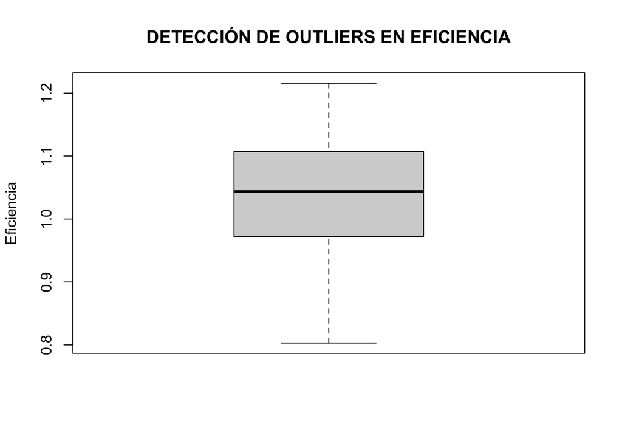

```r
###################### CREACION DE LA VARIABLE EFICIENCIA
# CALCULAMOS LA EFICIENCIA COMO RELACIÓN ENTRE normalized_power Y avg_heart_rate
sesiones_union <- sesiones_union %>%
  mutate(eficiencia = normalized_power / avg_heart_rate)

# DETECCION DE OUTLIERS EN EFICIENCIA
boxplot(sesiones_union$eficiencia,
        main = "DETECCIÓN DE OUTLIERS EN EFICIENCIA",
        ylab = "Eficiencia")
```

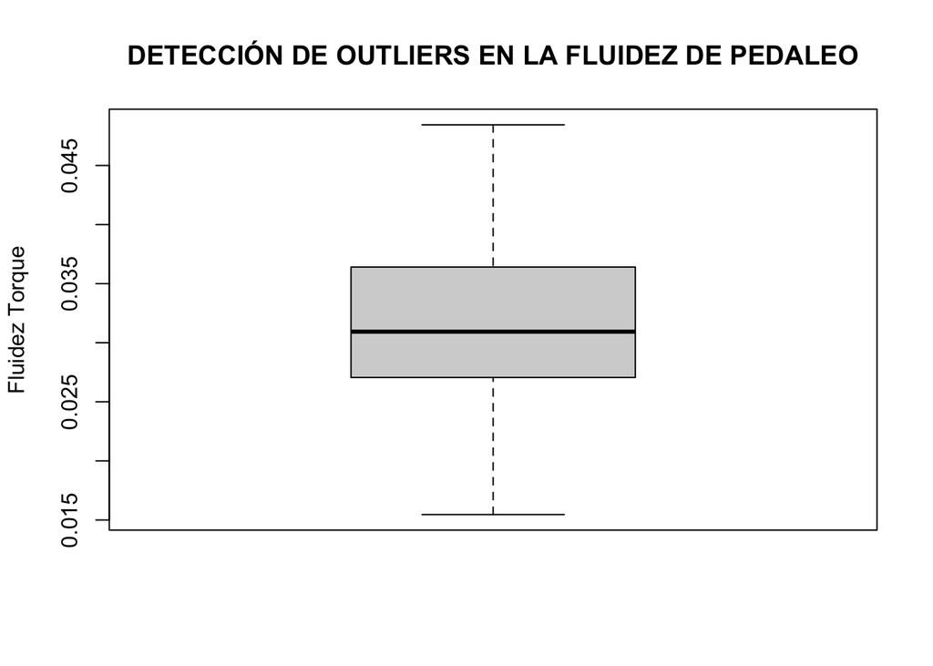

```r
# IMPUTACIÓN AUTOMÁTICA DE OUTLIERS EN EFICIENCIA
sesiones_union$eficiencia <- impute_outliers(sesiones_union$eficiencia)

###################### CREACION DE LA VARIABLE FLUIDEZ DEL TORQUE
# CALCULAMOS LA FLUIDEZ DEL TORQUE COMO RELACIÓN ENTRE max_power Y avg_power
sesiones_union <- sesiones_union %>%
  mutate(fluidez_torque = (max_power / avg_power) / 100)

# DETECCION DE OUTLIERS EN FLUIDEZ DEL TORQUE
boxplot(sesiones_union$fluidez_torque,
        main = "DETECCIÓN DE OUTLIERS EN LA FLUIDEZ DE PEDALEO",
        ylab = "Fluidez Torque")
```

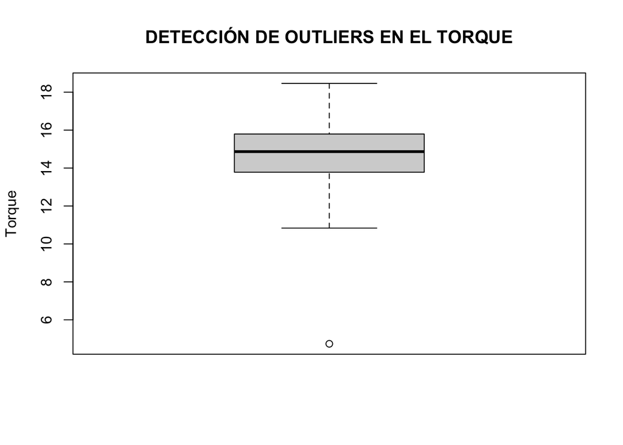

```r
# IMPUTACIÓN AUTOMÁTICA DE OUTLIERS EN FLUIDEZ DEL TORQUE
sesiones_union$fluidez_torque <- impute_outliers(sesiones_union$fluidez_torque)

###################### CREACION DE LA VARIABLE TORQUE
# CALCULAMOS EL TORQUE COMO PROMEDIO DE POTENCIA DIVIDIDO POR CADENCIA
sesiones_union <- sesiones_union %>%
  mutate(torque = avg_power / ((avg_cadence * 2 * pi) / 60))

# DETECCION DE OUTLIERS EN TORQUE
boxplot(sesiones_union$torque,
        main = "DETECCIÓN DE OUTLIERS EN EL TORQUE",
        ylab = "Torque")
```

```r
# IMPUTACIÓN AUTOMÁTICA DE OUTLIERS EN TORQUE
sesiones_union$torque <- impute_outliers(sesiones_union$torque)

###################### UNIR DATOS DE SESIONES CON DATOS DE EXCEL
# REALIZAMOS UNA UNIÓN IZQUIERDA ENTRE LOS DATOS DE EXCEL Y LAS SESIONES
sesiones_completo <- left_join(excel, sesiones_union, by = "date")
```

## Detección y Tratamiento de Outliers en Records

En este paso, se identifican y tratan los valores atípicos en las métricas principales del dataframe de registros (records). Se enfocan en potencia, frecuencia cardíaca y cadencia.

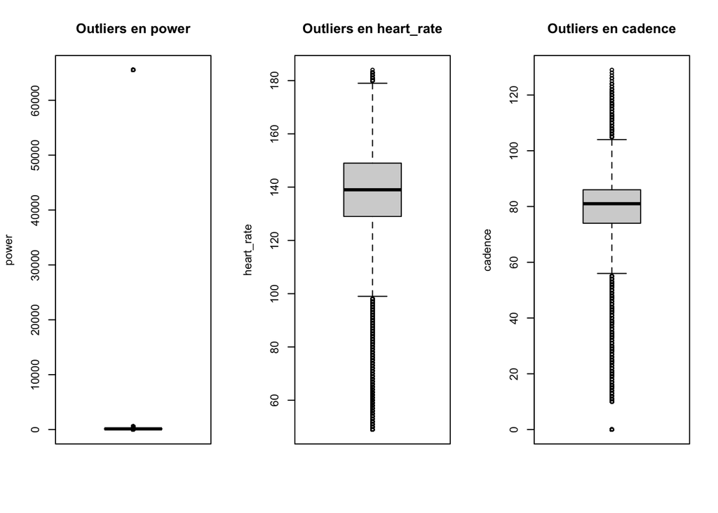

```r
###################### DETECCION DE OUTLIERS EN METRICAS DE RECORDS
# GRAFICAMOS LOS OUTLIERS EN LAS METRICAS CLAVE
metricas_records <- c("power", "heart_rate", "cadence")

par(mfrow = c(1, 3)) # CONFIGURAR GRID PARA VISUALIZAR
for (metrica in metricas_records) {
  boxplot(records_dataframe[[metrica]],
          main = paste("Outliers en", metrica),
          ylab = metrica)
}
```

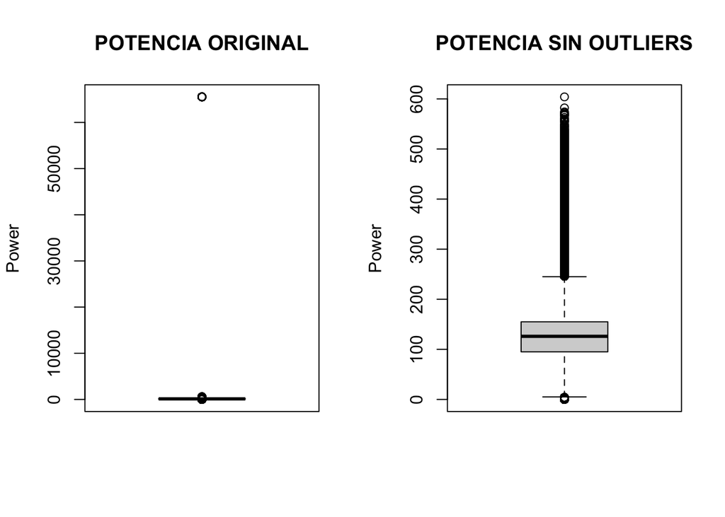

```r
par(mfrow = c(1, 1)) # REVERTIR EL GRID

###################### TRATAMIENTO DE OUTLIERS EN POTENCIA
# ELIMINAR OUTLIERS DE POTENCIA PONIENDO NA EN VALORES EXTREMOS
records_limpia <- records_dataframe %>%
  mutate(power = ifelse(power > 3000, NA, power))

###################### GRAFICAR DIFERENCIAS EN POTENCIA
# COMPARAR LA POTENCIA ORIGINAL Y LA POTENCIA SIN OUTLIERS
par(mfrow = c(1, 2))
boxplot(records_dataframe$power,
        main = "POTENCIA ORIGINAL",
        ylab = "Power")
boxplot(records_limpia$power,
        main = "POTENCIA SIN OUTLIERS",
        ylab = "Power")
```

```r
par(mfrow = c(1, 1))

###################### CONSIDERACIONES FUTURAS
# LLEGADOS A ESTE PUNTO TENEMOS REGISTROS ERRONEOS EN heart_rate.
# PARA MEJORAR ESTOS REGISTROS, SE PROPONE USAR UNA SERIE TEMPORAL
# MULTIVARIANTE QUE RELACIONE LA POTENCIA Y FRECUENCIA CARDIACA.
# ESTE ENFOQUE SERÁ IMPLEMENTADO POSTERIORMENTE.
```

## Guardar Datos Procesados

Este paso almacena los datos procesados en archivos locales para su uso posterior. Cada conjunto de datos se guarda en su respectivo archivo dentro de la carpeta de exportación.

```r
###################### GUARDAR SESIONES VIEJAS
# ALMACENAR EL DATAFRAME DE SESIONES ANTIGUAS EN UN ARCHIVO
save(sesiones_viejas,
     file = file.path(ruta_exportar, archivos$guardar_sesiones))

###################### GUARDAR DATOS COMPLETOS DE SESIONES
# ALMACENAR LA UNIÓN DE DATOS DE SESIONES Y EXCEL EN UN ARCHIVO
save(sesiones_completo,
     file = file.path(ruta_exportar, archivos$guardar_completo))

###################### GUARDAR LISTA DE RECORDS
# ALMACENAR LA LISTA COMPLETA DE RECORDS PROCESADOS EN UN ARCHIVO
save(records_lista,
     file = file.path(ruta_exportar, archivos$guardar_records_lista))

###################### GUARDAR DATAFRAME DE RECORDS
# ALMACENAR EL DATAFRAME DE RECORDS UNIFICADO EN UN ARCHIVO
save(records_dataframe,
     file = file.path(ruta_exportar, archivos$guardar_records))
```

## Limpieza y Preparación de Datos Unificados

En este paso, se seleccionan variables relevantes, se imputan valores faltantes y se crean nuevas variables para análisis avanzados.

```r
###################### SELECCIÓN DE VARIABLES CLAVE
# FILTRAMOS Y RENOMBRAMOS LAS VARIABLES RELEVANTES
sesion_limpia <- sesiones_completo %>%
  dplyr::select(
    fecha = date,
    peso,
    HRV,
    fc_basal = FcBasal,
    fc_media = avg_heart_rate,
    fc_max = FcMax,
    potencia_media = avg_power,
    potencia_normal = normalized_power,
    volumen = total_timer_time,
    intensidad = intensity_factor,
    distancia_total = total_distance,
    distancia_ascendida = total_ascent,
    TSS_TP = training_stress_score,
    deporte = sport,
    categoria = sub_sport,
    eficiencia,
    torque,
    fluidez_torque,
    FTP,
    T_05,
    T_012,
    T_030,
    T_1,
    T_5,
    T_20,
    T_60
  ) %>%
  mutate(ftp = FTP)

###################### IMPUTACIÓN DE VALORES FALTANTES

# HRV - USAMOS MODELO AUTOREGRESIVO (auto.arima)
sesion_limpia$HRV <- na_kalman(sesion_limpia$HRV, model = "auto.arima")

# PESO Y FC_BASAL - USAMOS MEDIAS MÓVILES
sesion_limpia$peso <- na_ma(sesion_limpia$peso, k = 10)
sesion_limpia$fc_basal <- na_ma(sesion_limpia$fc_basal, k = 10)

# FTP Y FC_MAX - USAMOS VALOR ANTERIOR
sesion_limpia$FTP <- na_locf(sesion_limpia$FTP)
sesion_limpia$fc_max <- na_locf(sesion_limpia$fc_max)

# OTRAS VARIABLES - SUSTITUIMOS FALTANTES POR CERO
vars_a_imputar <- c(
  "TSS_TP", "volumen", "intensidad", "fc_media",
  "potencia_media", "potencia_normal", "distancia_total",
  "distancia_ascendida"
)
sesion_limpia <- sesion_limpia %>%
  mutate(across(all_of(vars_a_imputar), ~ replace_na(., 0)))

###################### CREACIÓN DE VARIABLES DE FATIGA
# ATL_TP (ACUTE TRAINING LOAD) Y CTL_TP (CHRONIC TRAINING LOAD)
sesion_limpia <- sesion_limpia %>%
  mutate(
    ATL_TP = EMA(TSS_TP, n = 7),
    CTL_TP = EMA(TSS_TP, n = 42)
  )

# AJUSTE DE VALORES FALTANTES PARA FATIGA
sesion_limpia$ATL_TP[1:1] <- 60
sesion_limpia$ATL_TP <- na_ma(sesion_limpia$ATL_TP, k = 7, weighting = "exponential")
sesion_limpia$CTL_TP[1:1] <- 60
sesion_limpia$CTL_TP <- na_kalman(sesion_limpia$CTL_TP, model = "auto.arima")

###################### CREACIÓN DE VARIABLES DERIVADAS
# TSB_TP (TRAINING STRESS BALANCE)
sesion_limpia <- sesion_limpia %>%
  mutate(TSB_TP = CTL_TP - ATL_TP)

# IDENTIFICADOR DEL ATLETA
sesion_limpia <- sesion_limpia %>%
  mutate(atleta = atleta)

###################### VARIABLES TEMPORALES
# AGREGAMOS SEMANA Y MES A PARTIR DE LA FECHA
sesion_limpia <- sesion_limpia %>%
  mutate(
    semana = strftime(fecha, "%V"),
    mes = strftime(fecha, "%m")
  )
```

## Guardar Sesión Limpia

Este paso almacena la sesión limpia con las variables seleccionadas y los datos imputados, asegurando su disponibilidad para futuros análisis.

```r
###################### GUARDAR SESION LIMPIA
# ALMACENAMOS EL DATAFRAME LIMPIO EN UN ARCHIVO LOCAL
save(sesion_limpia,
     file = file.path(ruta_exportar, archivos$guardar_limpias))
```

## Comparación: Training Peaks vs Datos Calculados

En este paso, se crean variables propias de carga (TSS, ATL, CTL, TSB) a partir de los datos limpios y se comparan con los cálculos de Training Peaks.

```r
###################### CREACIÓN DE VARIABLES DE CARGA PROPIAS PARA COMPARAR
# CALCULAMOS VARIABLES BASADAS EN POTENCIA, VOLUMEN E FTP
variables_calculadas <- sesion_limpia %>%
  dplyr::select(
    fecha,
    FTP,
    potencia_normal,
    volumen
  ) %>%
  mutate(
    intensidad = potencia_normal / FTP, # CALCULAMOS INTENSIDAD RELATIVA
    TSS = (volumen * potencia_normal * intensidad) / (FTP * 3600) * 100, # CALCULAMOS TSS
    ATL = EMA(TSS, n = 7),             # CALCULAMOS ATL (ACUTE TRAINING LOAD)
    CTL = EMA(TSS, n = 42)             # CALCULAMOS CTL (CHRONIC TRAINING LOAD)
  )

###################### IMPUTACIÓN DE VALORES FALTANTES EN CARGA

# IMPUTACIÓN DE ATL (CARGA AGUDA) CON MEDIA MÓVIL EXPONENCIAL
variables_calculadas$ATL[1] <- 60
variables_calculadas$ATL <- na_ma(variables_calculadas$ATL, k = 7, weighting = "exponential")

# IMPUTACIÓN DE CTL (CARGA CRÓNICA) CON MODELO AUTOREGRESIVO
variables_calculadas$CTL[1] <- 60
variables_calculadas$CTL <- na_kalman(variables_calculadas$CTL, model = "auto.arima")

###################### CREACIÓN DE LA VARIABLE DE BALANCE DE ESTRÉS
# TSB (TRAINING STRESS BALANCE) COMO DIFERENCIA ENTRE CTL Y ATL
variables_calculadas <- variables_calculadas %>%
  mutate(TSB = CTL - ATL)
```

## Graficar Diferencias: Intensidad Calculada vs Training Peaks

Este paso compara visualmente la intensidad calculada con los datos proporcionados por Training Peaks utilizando gráficos interactivos.

```r
###################### PREPARAR DATOS PARA GRAFICAR
# COMBINAMOS LAS INTENSIDADES CALCULADAS Y DE TRAINING PEAKS EN UNA SERIE TEMPORAL
variables_intensidad <- ts(
  cbind.data.frame(
    Calculada = variables_calculadas$intensidad,     # INTENSIDAD CALCULADA
    TrainingPeaks = sesion_limpia$intensidad         # INTENSIDAD DESDE TRAINING PEAKS
  )
)

###################### GRAFICAR DIFERENCIAS EN INTENSIDAD
# USAMOS dygraph PARA CREAR UN GRÁFICO INTERACTIVO
dygraph(variables_intensidad) %>%
  dySeries("Calculada", label = "Intensidad Calculada") %>%
  dySeries("TrainingPeaks", label = "Intensidad Training Peaks") %>%
  dyOptions(colors = RColorBrewer::brewer.pal(2, "Set1")) %>%
  dyLegend(show = "always", hideOnMouseOut = FALSE) %>%
  dyAxis("y", label = "Intensidad Relativa") %>%
  dyAxis("x", label = "Tiempo") %>%
  dyRangeSelector()
```

[interactive chart not shown]

## Graficar Diferencias: TSS Calculado vs Training Peaks

Este paso compara visualmente el Training Stress Score (TSS) calculado con el reportado por Training Peaks utilizando gráficos interactivos.

```r
###################### PREPARAR DATOS PARA GRAFICAR
# COMBINAMOS EL TSS CALCULADO Y EL DE TRAINING PEAKS EN UNA SERIE TEMPORAL
variables_carga <- ts(
  cbind.data.frame(
    Calculado = variables_calculadas$TSS,    # TSS CALCULADO
    TrainingPeaks = sesion_limpia$TSS_TP     # TSS DESDE TRAINING PEAKS
  )
)

###################### GRAFICAR DIFERENCIAS EN TSS
# USAMOS dygraph PARA CREAR UN GRÁFICO INTERACTIVO
dygraph(variables_carga) %>%
  dySeries("Calculado", label = "TSS Calculado") %>%
  dySeries("TrainingPeaks", label = "TSS Training Peaks") %>%
  dyOptions(colors = RColorBrewer::brewer.pal(2, "Set2")) %>%
  dyLegend(show = "always", hideOnMouseOut = FALSE) %>%
  dyAxis("y", label = "Training Stress Score (TSS)") %>%
  dyAxis("x", label = "Tiempo") %>%
  dyRangeSelector()
```

[interactive chart not shown]

## Graficar Diferencias: ATL Calculado vs Training Peaks

Este paso compara visualmente la carga aguda (ATL) calculada con los datos proporcionados por Training Peaks.

```r
###################### PREPARAR DATOS PARA GRAFICAR
# COMBINAMOS EL ATL CALCULADO Y EL DE TRAINING PEAKS EN UNA SERIE TEMPORAL
variables_carga_aguda <- ts(
  cbind.data.frame(
    Calculado = variables_calculadas$ATL,     # ATL CALCULADO
    TrainingPeaks = sesion_limpia$ATL_TP      # ATL DESDE TRAINING PEAKS
  )
)

###################### GRAFICAR DIFERENCIAS EN ATL
# USAMOS dygraph PARA CREAR UN GRÁFICO INTERACTIVO
dygraph(variables_carga_aguda) %>%
  dySeries("Calculado", label = "ATL Calculado") %>%
  dySeries("TrainingPeaks", label = "ATL Training Peaks") %>%
  dyOptions(colors = RColorBrewer::brewer.pal(2, "Set1")) %>%
  dyLegend(show = "always", hideOnMouseOut = FALSE) %>%
  dyAxis("y", label = "Acute Training Load (ATL)") %>%
  dyAxis("x", label = "Tiempo") %>%
  dyRangeSelector()
```

[interactive chart not shown]

## Graficar Diferencias: CTL Calculado vs Training Peaks

Este paso compara visualmente la carga crónica (CTL) calculada con los datos proporcionados por Training Peaks.

```r
###################### PREPARAR DATOS PARA GRAFICAR
# COMBINAMOS EL CTL CALCULADO Y EL DE TRAINING PEAKS EN UNA SERIE TEMPORAL
variables_carga_cronica <- ts(
  cbind.data.frame(
    Calculado = variables_calculadas$CTL,     # CTL CALCULADO
    TrainingPeaks = sesion_limpia$CTL_TP      # CTL DESDE TRAINING PEAKS
  )
)

###################### GRAFICAR DIFERENCIAS EN CTL
# USAMOS dygraph PARA CREAR UN GRÁFICO INTERACTIVO
dygraph(variables_carga_cronica) %>%
  dySeries("Calculado", label = "CTL Calculado") %>%
  dySeries("TrainingPeaks", label = "CTL Training Peaks") %>%
  dyOptions(colors = RColorBrewer::brewer.pal(2, "Set2")) %>%
  dyLegend(show = "always", hideOnMouseOut = FALSE) %>%
  dyAxis("y", label = "Chronic Training Load (CTL)") %>%
  dyAxis("x", label = "Tiempo") %>%
  dyRangeSelector()
```

[interactive chart not shown]

## Graficar Diferencias: TSB Calculado vs Training Peaks

Este paso compara visualmente el estado de forma (TSB) calculado con los datos proporcionados por Training Peaks.

```r
###################### PREPARAR DATOS PARA GRAFICAR
# COMBINAMOS EL TSB CALCULADO Y EL DE TRAINING PEAKS EN UNA SERIE TEMPORAL
variables_forma <- ts(
  cbind.data.frame(
    Calculado = variables_calculadas$TSB,     # TSB CALCULADO
    TrainingPeaks = sesion_limpia$TSB_TP      # TSB DESDE TRAINING PEAKS
  )
)

###################### GRAFICAR DIFERENCIAS EN TSB
# USAMOS dygraph PARA CREAR UN GRÁFICO INTERACTIVO
dygraph(variables_forma) %>%
  dySeries("Calculado", label = "TSB Calculado") %>%
  dySeries("TrainingPeaks", label = "TSB Training Peaks") %>%
  dyOptions(colors = RColorBrewer::brewer.pal(2, "Dark2")) %>%
  dyLegend(show = "always", hideOnMouseOut = FALSE) %>%
  dyAxis("y", label = "Training Stress Balance (TSB)") %>%
  dyAxis("x", label = "Tiempo") %>%
  dyRangeSelector()
```

[interactive chart not shown]

## Relación entre Eficiencia y Tiempo/Volumen

En este paso, se analiza la relación entre la eficiencia del atleta y su evolución temporal, así como su relación con el volumen de entrenamiento.

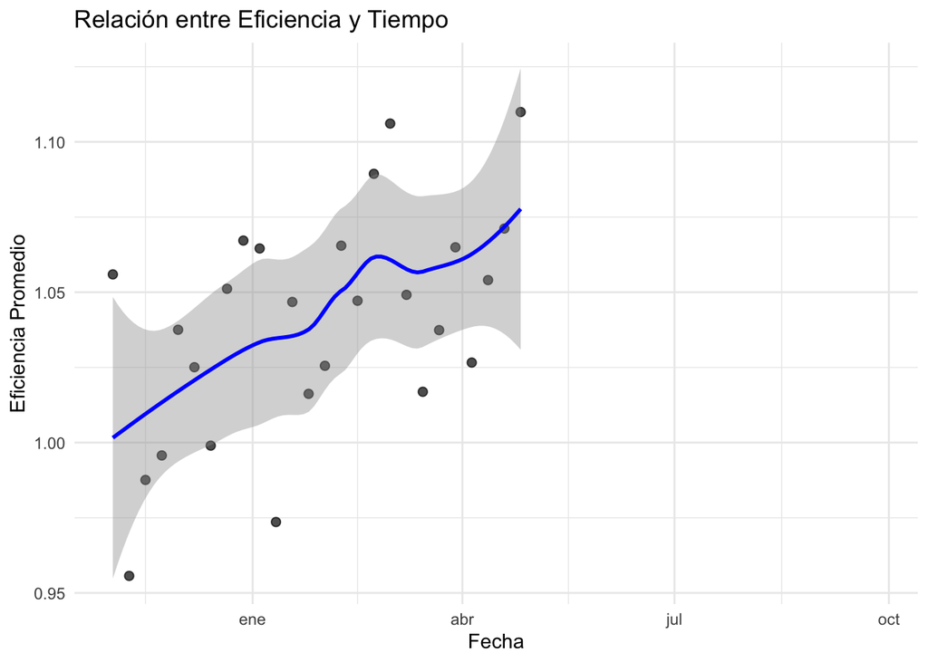

```r
###################### ANALIZAR RELACION EFICIENCIA Y TIEMPO
# CALCULAMOS LA EFICIENCIA PROMEDIO POR SEMANA
relacion_eficiencia_tiempo <- sesion_limpia %>%
  dplyr::select(fecha, eficiencia, semana) %>%
  group_by(semana) %>%
  summarise(
    eficiencia = mean(ifelse(eficiencia == 0, NA, eficiencia), na.rm = TRUE),
    fecha = first(fecha)
  )

###################### ANALIZAR RELACION EFICIENCIA Y VOLUMEN
# CALCULAMOS LA RELACION ENTRE EFICIENCIA Y VOLUMEN POR SEMANA
relacion_eficiencia_volumen <- sesion_limpia %>%
  dplyr::select(eficiencia, volumen, semana) %>%
  group_by(semana) %>%
  summarise(
    eficiencia = mean(ifelse(eficiencia == 0, NA, eficiencia), na.rm = TRUE),
    volumen = sum(volumen)
  )

###################### GRAFICAR RELACION EFICIENCIA Y TIEMPO
ggplot(relacion_eficiencia_tiempo, aes(x = fecha, y = eficiencia)) +
  geom_point(size = 2, alpha = 0.7) +
  geom_smooth(method = "loess", se = TRUE, color = "blue") +
  labs(
    title = "Relación entre Eficiencia y Tiempo",
    x = "Fecha",
    y = "Eficiencia Promedio"
  ) +
  theme_minimal()
```

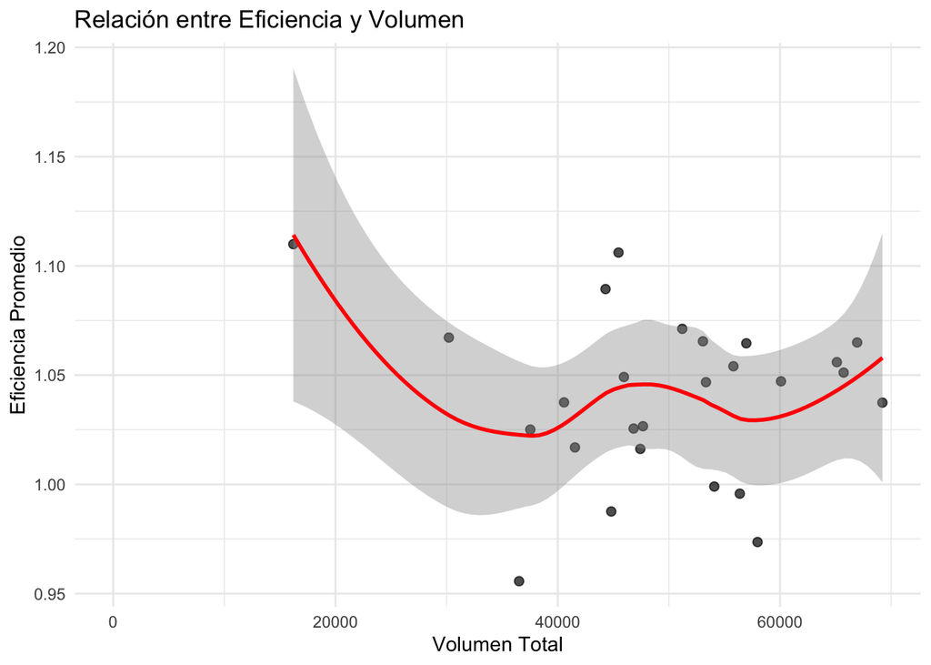

```r
###################### GRAFICAR RELACION EFICIENCIA Y VOLUMEN
ggplot(relacion_eficiencia_volumen, aes(x = volumen, y = eficiencia)) +
  geom_point(size = 2, alpha = 0.7) +
  geom_smooth(method = "loess", se = TRUE, color = "red") +
  labs(
    title = "Relación entre Eficiencia y Volumen",
    x = "Volumen Total",
    y = "Eficiencia Promedio"
  ) +
  theme_minimal()
```

## Gráficos: Torque y Fluidez de Pedaleo en el Tiempo

En este paso, se visualizan las tendencias del torque y la fluidez de pedaleo del atleta a lo largo del tiempo.

### Graficar Torque en el Tiempo

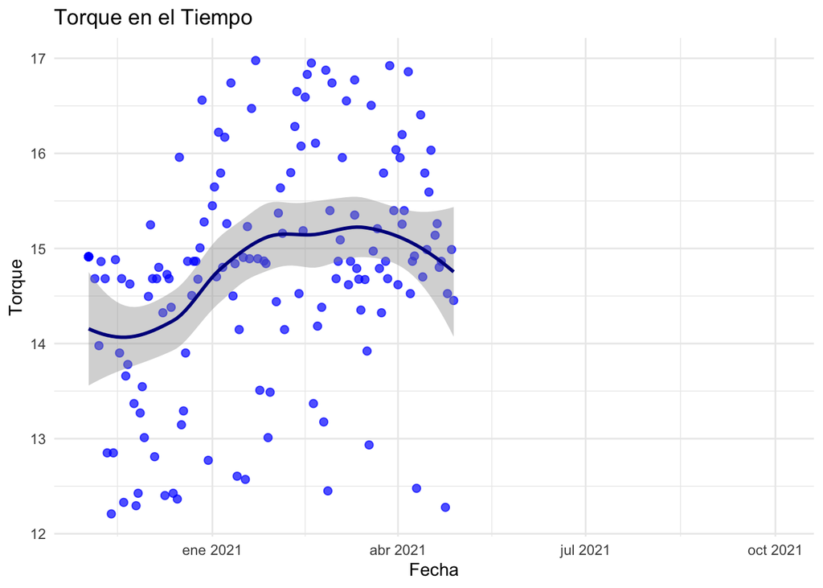

```r
###################### GRAFICAR TORQUE EN EL TIEMPO
# VISUALIZAMOS LA RELACIÓN ENTRE EL TORQUE Y EL TIEMPO
ggplot(sesion_limpia, aes(x = fecha, y = torque)) +
  geom_point(size = 2, alpha = 0.7, color = "blue") +
  geom_smooth(method = "loess", se = TRUE, color = "darkblue") +
  labs(
    title = "Torque en el Tiempo",
    x = "Fecha",
    y = "Torque"
  ) +
  theme_minimal()
```

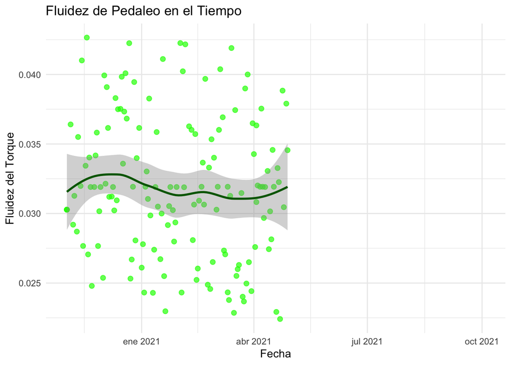

```r
###################### GRAFICAR FLUIDEZ DE PEDALEO EN EL TIEMPO
# VISUALIZAMOS LA RELACIÓN ENTRE LA FLUIDEZ DE PEDALEO Y EL TIEMPO
ggplot(sesion_limpia, aes(x = fecha, y = fluidez_torque)) +
  geom_point(size = 2, alpha = 0.7, color = "green") +
  geom_smooth(method = "loess", se = TRUE, color = "darkgreen") +
  labs(
    title = "Fluidez de Pedaleo en el Tiempo",
    x = "Fecha",
    y = "Fluidez del Torque"
  ) +
  theme_minimal()
```

## Análisis Previo a la Serie Temporal

En este paso, se seleccionan las variables clave para el análisis y se realiza un tratamiento inicial de los valores atípicos.

```r
###################### SELECCIONAR VARIABLES PARA EL ANÁLISIS
# EXTRAEMOS LAS VARIABLES RELEVANTES DE RECORDS LIMPIOS
records_small <- records_limpia %>%
  dplyr::select(
    fecha = timestamp,       # FECHA DEL REGISTRO
    frecuencia = heart_rate, # FRECUENCIA CARDIACA
    potencia = power,        # POTENCIA GENERADA
    cadencia = cadence       # CADENCIA DE PEDALEO
  )

###################### SUSTITUCIÓN DE OUTLIERS POR NA
# LOS VALORES DE FRECUENCIA CARDIACA SUPERIORES A 215 SON CONSIDERADOS OUTLIERS
records_small <- records_small %>%
  mutate(frecuencia = ifelse(frecuencia > 215, NA, frecuencia))
```